# Proposed Data Management Flow

## Proposed Data Management and Analytics Flow

### Needs and Existing Alternatives

#### Need 1:

The current system uses different Google Sheets to track attendance for members, workers and visitors. It also uses names as observations (rows) and dates as variables (columns).

#### Alternatives 1:

1. Create a clean and tidy master database of church members, workers, and visitors with a column for "membership status"
2. Transform the attendance sheet to have dates as rows, instead of columns. Connect it to the master database with a primary key (e.g. name); then absentees can be extracted
3. Store data in a database - long term
4. Use Power Apps and Power Automate to aid data entry via an app on mobile or tablet and notify leaders of new entries - long term
5. Consider switching to MS Excel to create a Form that aids data entry in the sheet - short term

Master database with membership status column

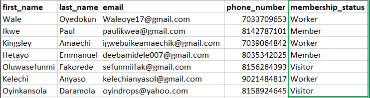

Attendance sheet with dates as rows

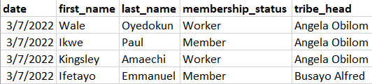

Demo of attendance data entry using Power Apps **(best option)**

[figure not shown]

or using a form in MS Excel so one doesn't have to scroll to the end of the sheet to input data

[figure not shown]

Demo of First timers entry via Power Apps

[figure not shown]

Get notified via push notifications

[figure not shown]

#### Need 2:

Insights on attendance and Tribes members locations are summarized in a pivot table

#### Alternative 2:

1. Summary statistics in a pivot table are great. Visualizations are even better and dynamic charts can be set up with MS Excel or Power BI to show these insights at a glance, by default.
2. We can also monitor first-timers' conversion rates with vizzes.

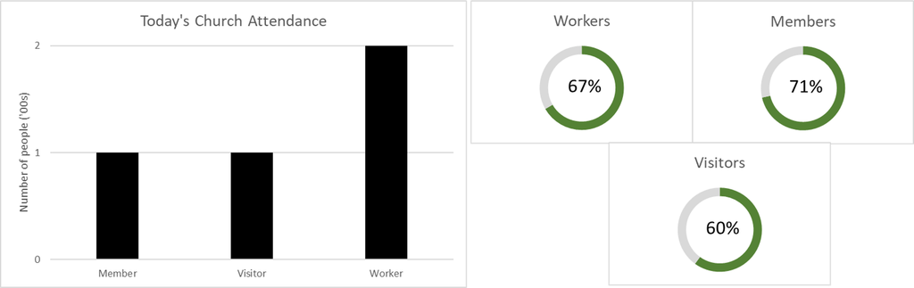

### Unique Value Proposition

Imagine being able to register attendance, keep track of your tribes members who were present or absent, and get notified when new people join your tribe. Also imagine being able to, at a glance, track attendance trends and first timers conversion rates. All from an app. That’s the goal.

### WhiteBoard

1. Clean all datasets - **should take 1.5weeks from approval**
2. Choose data entry method - **either Power Apps or MS Excel**
3. Determine common insights needed - **for visualization**
4. Discuss Power Platform integration on **Sunday, 10th of July**.